# Examen minería datos II

## 3.10. Model glmboost

```r
#set.seed(123)
#glmboostGrid <-  expand.grid(mstop = 1:50, prune=c(0.1, 0.01, 0.5, 0.9, 1, 1.1, 1.5, 2))
#clusterCPU <- registerDoParallel(cores=detectCores() - 1)
#glmboost.fit <- train(x = data.training[, names(data.training) != "y", with=FALSE],
#             y = data.training$y,
#             method = "glmboost",
#             preProc = c("center", "scale"),
#             trControl = train.control,
#             metric = metrica,
#              tuneGrid = glmboostGrid
#             )
#stopImplicitCluster()

#saveRDS(glmboost.fit, file = "glmboost.rds")

glmboost.fit <- readRDS(file = "glmboost.rds")
get_model_results(glmboost.fit, data.training, data.testing, TRUE, TRUE)
```

```
## [1] "Resultados para cada uno de los parámetros de la malla:"
## Boosted Generalized Linear Model
##
## 1000 samples
##    7 predictor
##    2 classes: 'No', 'Yes'
##
## Pre-processing: centered (7), scaled (7)
## Resampling: Cross-Validated (10 fold, repeated 5 times)
## Summary of sample sizes: 900, 900, 900, 900, 900, 900, ...
## Resampling results across tuning parameters:
##
##   mstop  prune  ROC       Sens    Spec    Accuracy  Kappa
##    1     0.01   0.844944  0.9812  0.6796  0.8304    0.6608
##    1     0.10   0.844944  0.9812  0.6796  0.8304    0.6608
```

[output cut: 447 more lines]

```
##
## NOTE: Coefficients from a Binomial model are half the size of coefficients
##  from a model fitted via glm(... , family = 'binomial').
## See Warning section in ?coef.mboost
```

```
## glmboost variable importance
##
##     Overall
## V16  100.00
## V2    56.99
## V1     0.00
## V22    0.00
## V26    0.00
## V8     0.00
## V25    0.00
## [1] "Gráfico ROC-parámetros:"
```

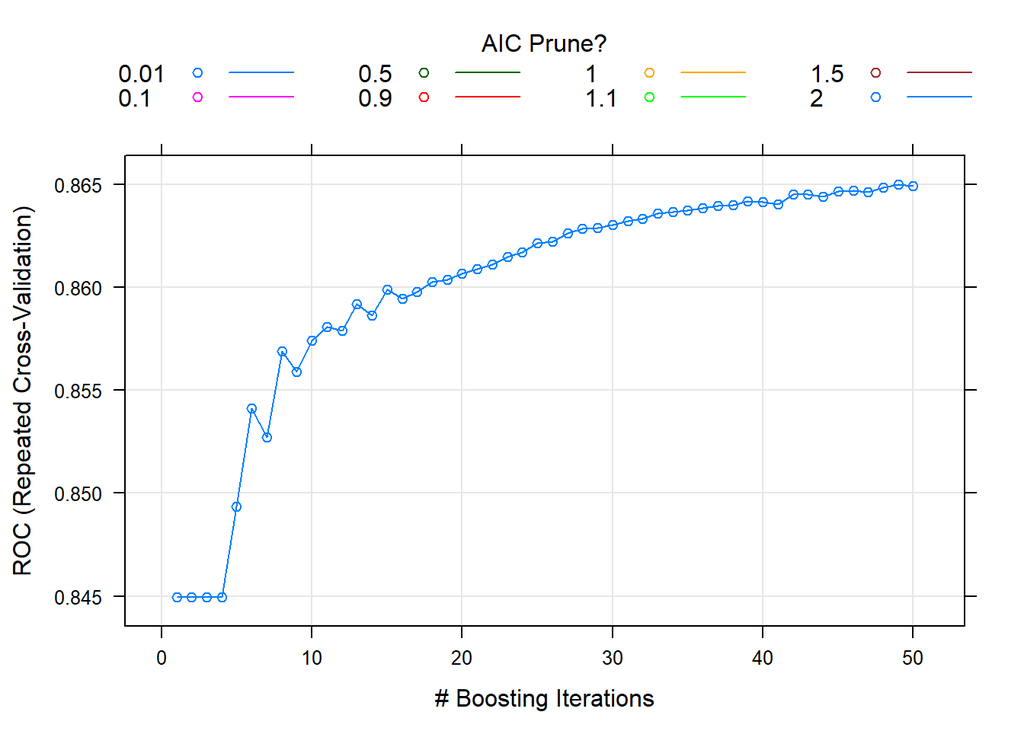

```
## [1] "Curva ROC:"
```

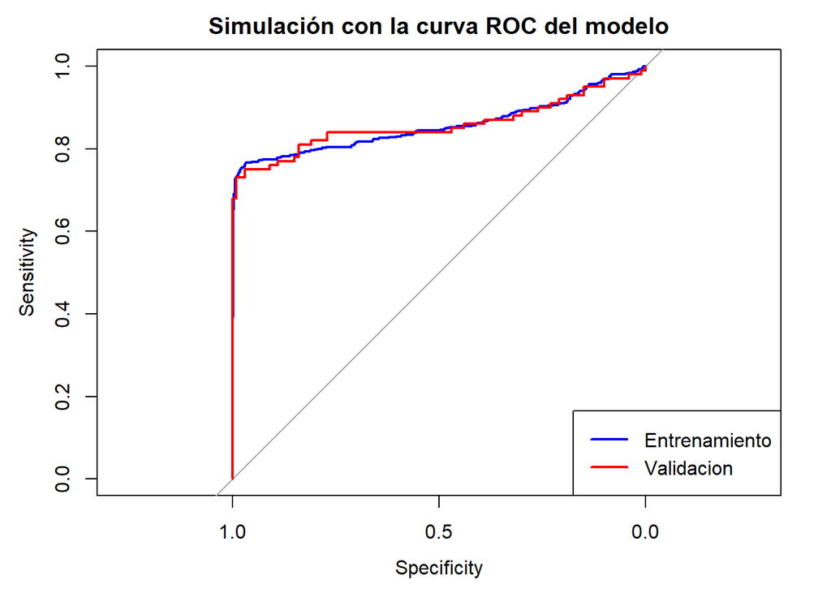

```r
plot_roc_curve(glmboost.fit, data.training, data.testing)
```

## 3.11. Model logistboost

```r
#set.seed(123)
#logistboostGrid <-  expand.grid(nIter = 1:14)
#clusterCPU <- registerDoParallel(cores=detectCores() - 1)
#logitboost.fit <- train(x = data.training[, names(data.training) != "y", with=FALSE],
#             y = data.training$y,
#             method = "LogitBoost",
#             preProc = c("center", "scale"),
#             trControl = train.control,
#             metric = metrica,
#              tuneGrid = logistboostGrid
#             )
#stopImplicitCluster()

#saveRDS(logitboost.fit, file = "logitboost.rds")

logitboost.fit <- readRDS(file = "logitboost.rds")

get_model_results(logitboost.fit, data.training, data.testing, TRUE, TRUE)
```

```
## [1] "Resultados para cada uno de los parámetros de la malla:"
## Boosted Logistic Regression
##
## 1000 samples
##    7 predictor
##    2 classes: 'No', 'Yes'
##
## Pre-processing: centered (7), scaled (7)
## Resampling: Cross-Validated (10 fold, repeated 5 times)
## Summary of sample sizes: 900, 900, 900, 900, 900, 900, ...
## Resampling results across tuning parameters:
##
##   nIter  ROC       Sens       Spec       Accuracy   Kappa
##    1     0.834200  0.9460000  0.7224000  0.8342000  0.6684000
##    2     0.898140  0.9971936  0.8594326  0.9273514  0.8546813
##    3     0.907728  0.9184000  0.7740000  0.8462000  0.6924000
##    4     0.902100  0.9135085  0.8899075  0.9014044  0.8015750
##    5     0.913624  0.9196000  0.8080000  0.8638000  0.7276000
##    6     0.913780  0.9232134  0.9045807  0.9129838  0.8244990
##    7     0.917000  0.9304000  0.8092000  0.8698000  0.7396000
##    8     0.916740  0.9405155  0.8878337  0.9128882  0.8249259
##    9     0.919060  0.9260000  0.8160000  0.8710000  0.7420000
##   10     0.919316  0.9368834  0.8944987  0.9150762  0.8294153
##   11     0.921460  0.9280000  0.8164000  0.8722000  0.7444000
##   12     0.921608  0.9440190  0.8858275  0.9138871  0.8273465
##   13     0.922452  0.9120000  0.8292000  0.8706000  0.7412000
##   14     0.919804  0.9330693  0.8907290  0.9118438  0.8229951
##
## ROC was used to select the optimal model using the largest value.
## The final value used for the model was nIter = 13.
## [1] "#######################################################"
## [1] "Matriz de confusión del modelo:"
## [1] "#######################################################"
## Cross-Validated (10 fold, repeated 5 times) Confusion Matrix
##
## (entries are percentual average cell counts across resamples)
##
##           Reference
## Prediction   No  Yes
##        No  45.6  8.5
```

[output cut: 32 more lines]

```
##        'Positive' Class : No
##
## [1] "#######################################################"
## [1] "Importancia de las variables:"
## ROC curve variable importance
##
##     Importance
## V2     100.000
## V16     94.083
## V1      80.162
## V8      41.284
## V26     12.962
## V22      7.234
## V25      0.000
## [1] "Gráfico ROC-parámetros:"
```

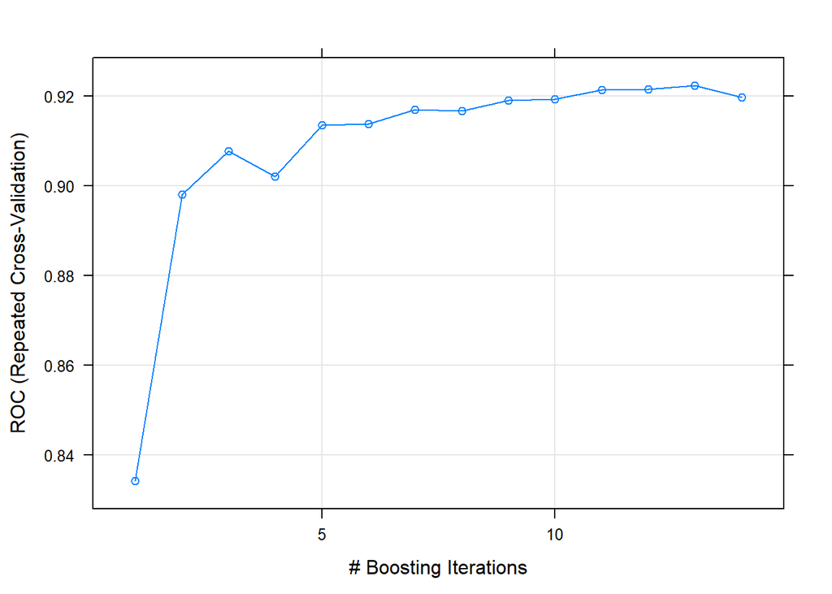

```
## [1] "Curva ROC:"
```

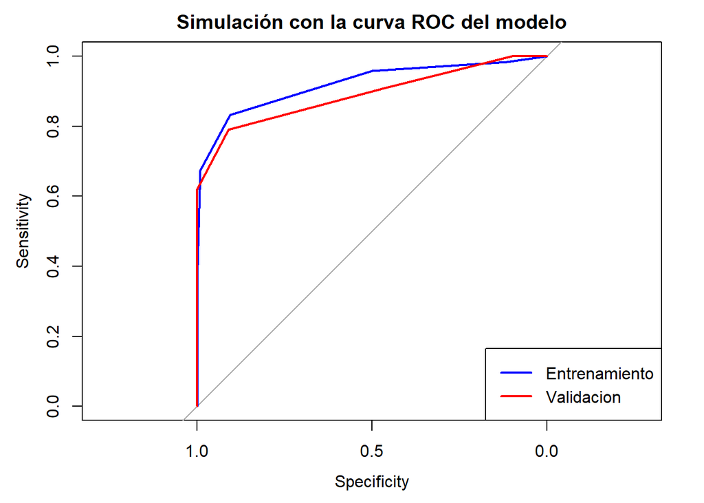

```r
plot_roc_curve(logitboost.fit, data.training, data.testing)
```

## 3.12. Model bagging

```r
#set.seed(123)
#clusterCPU <- registerDoParallel(cores=detectCores() - 1)
#bagGrid <-  expand.grid(vars  = 1:50)
#bag.fit <- train(x = data.training[, names(data.training) != "y", with=FALSE],
#             y = data.training$y,
#             method = "bag",
#             preProc = c("center", "scale"),
#             trControl = train.control,
#             metric = metrica,
#             tuneGrid = bagGrid
#             )
#stopImplicitCluster()


#saveRDS(bag.fit, file = "bag.rds")

bag.fit <- readRDS(file = "bag.rds")

get_model_results(bag.fit, data.training, data.testing, FALSE, TRUE)
```

```
## [1] "Resultados para cada uno de los parámetros de la malla:"
## Bagged CART
##
## 1000 samples
##    7 predictor
##    2 classes: 'No', 'Yes'
##
## Pre-processing: centered (7), scaled (7)
## Resampling: Cross-Validated (10 fold, repeated 5 times)
## Summary of sample sizes: 900, 900, 900, 900, 900, 900, ...
## Resampling results:
##
##   ROC       Sens    Spec   Accuracy  Kappa
##   0.952136  0.9324  0.868  0.9002    0.8004
##
## [1] "#######################################################"
## [1] "Matriz de confusión del modelo:"
## [1] "#######################################################"
## Cross-Validated (10 fold, repeated 5 times) Confusion Matrix
##
## (entries are percentual average cell counts across resamples)
##
##           Reference
## Prediction   No  Yes
##        No  46.6  6.6
##        Yes  3.4 43.4
##
##  Accuracy (average) : 0.9002
##
## [1] "#######################################################"
## [1] "Matriz de confusión comparando las predicciones del modelo y los datos de test:"
## [1] "#######################################################"
## Confusion Matrix and Statistics
##
##           Reference
## Prediction No Yes
##        No  98  13
##        Yes  2  87
##
##                Accuracy : 0.925
```

[output cut: 16 more lines]

```
##
##        'Positive' Class : No
##
## [1] "#######################################################"
## [1] "Importancia de las variables:"
## treebag variable importance
##
##     Overall
## V16 100.000
## V2   87.988
## V1   57.128
## V8   37.929
## V25   6.381
## V22   1.889
## V26   0.000
```

```
## [1] "Curva ROC:"
```

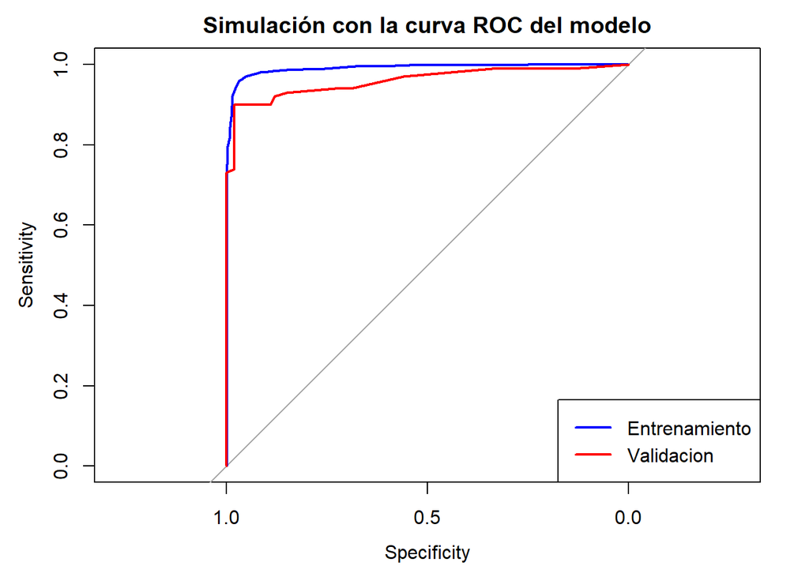

```r
plot_roc_curve(bag.fit, data.training, data.testing)
```

## 3.13. Modelo adabag

```r
#set.seed(123)
#clusterCPU <- registerDoParallel(cores=detectCores() - 1)
#adabag.fit <- train(x = data.training[, names(data.training) != "y", with=FALSE],
#             y = data.training$y,
#             method = "AdaBag",
#             preProc = c("center", "scale"),
#             trControl = train.control,
#             metric = metrica
#             #tuneGrid = bagGrid
#             )
#stopImplicitCluster()

#saveRDS(adabag.fit, file = "adabag.rds")

adabag.fit <- readRDS(file = "adabag.rds")

get_model_results(adabag.fit, data.training, data.testing, FALSE, TRUE)
```

```
## [1] "Resultados para cada uno de los parámetros de la malla:"
## Bagged AdaBoost
##
## 1000 samples
##    7 predictor
##    2 classes: 'No', 'Yes'
##
## Pre-processing: centered (7), scaled (7)
## Resampling: Cross-Validated (10 fold, repeated 5 times)
## Summary of sample sizes: 900, 900, 900, 900, 900, 900, ...
## Resampling results across tuning parameters:
##
##   maxdepth  mfinal  ROC       Sens    Spec    Accuracy  Kappa
##   1          50     0.864116  0.9740  0.7092  0.8416    0.6832
##   1         100     0.867968  0.9752  0.7092  0.8422    0.6844
##   1         150     0.869656  0.9760  0.7084  0.8422    0.6844
##   2          50     0.914924  0.8880  0.7972  0.8426    0.6852
##   2         100     0.916836  0.8900  0.7884  0.8392    0.6784
##   2         150     0.918084  0.8840  0.7948  0.8394    0.6788
##   3          50     0.936924  0.9720  0.7888  0.8804    0.7608
##   3         100     0.940760  0.9708  0.7900  0.8804    0.7608
##   3         150     0.942320  0.9700  0.7912  0.8806    0.7612
##
## ROC was used to select the optimal model using the largest value.
## The final values used for the model were mfinal = 150 and maxdepth = 3.
## [1] "#######################################################"
## [1] "Matriz de confusión del modelo:"
## [1] "#######################################################"
## Cross-Validated (10 fold, repeated 5 times) Confusion Matrix
##
## (entries are percentual average cell counts across resamples)
##
##           Reference
## Prediction   No  Yes
##        No  48.5 10.4
##        Yes  1.5 39.6
##
##  Accuracy (average) : 0.8806
##
## [1] "#######################################################"
```

[output cut: 26 more lines]

```
##
##        'Positive' Class : No
##
## [1] "#######################################################"
## [1] "Importancia de las variables:"
## AdaBag variable importance
##
##      Overall
## V16 100.0000
## V2   14.2890
## V1   11.6671
## V8    2.8472
## V25   0.2894
## V26   0.1896
## V22   0.0000
```

```
## [1] "Curva ROC:"
```

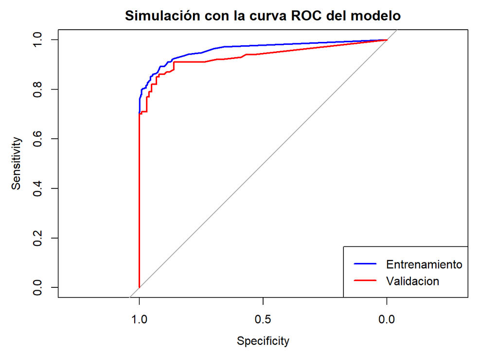

```r
plot_roc_curve(adabag.fit, data.training, data.testing)
```

## 3.14. Modelo boosting (xgbTree)

```r
#set.seed(123)
#xbgTreeGrid <-  expand.grid(nrounds  = 1:20,
#                            max_depth = 1:10,
#                            eta = c(0.01, 0.015, 0.020, 0.025),
#                            gamma=1:5,
#                            colsample_bytree = c( 0.4, 0.6, 0.8, 1.0 ),
#                            min_child_weight = 1:5,
#                            subsample = c( 0.5, 0.75, 1.0 ))
#clusterCPU <- registerDoParallel(cores=detectCores() - 1)
#bagGrid <-  expand.grid(vars  = 1:50)
#adabag.fit <- train(x = data.training[, names(data.training) != "y", with=FALSE],
#             y = data.training$y,
#             method = "xgbTree",
#             preProc = c("center", "scale"),
#             trControl = train.control,
#             metric = metrica,
#             tuneGrid = xbgTreeGrid
#             )
#stopImplicitCluster()

#saveRDS(xgbTree.fit, file = "xgbTree.rds")

xgbTree.fit <- readRDS(file = "xgbTree.rds")


get_model_results(xgbTree.fit, data.training, data.testing, FALSE, TRUE)
```

```
## [1] "Resultados para cada uno de los parámetros de la malla:"
## eXtreme Gradient Boosting
##
## 1000 samples
##    7 predictor
##    2 classes: 'No', 'Yes'
##
## Pre-processing: centered (7), scaled (7)
## Resampling: Cross-Validated (10 fold, repeated 5 times)
## Summary of sample sizes: 900, 900, 900, 900, 900, 900, ...
## Resampling results across tuning parameters:
##
##   eta    max_depth  gamma  colsample_bytree  min_child_weight  subsample
##   0.010   1         1      0.4               1                 0.50
##   0.010   1         1      0.4               1                 0.50
##   0.010   1         1      0.4               1                 0.50
##   0.010   1         1      0.4               1                 0.50
##   0.010   1         1      0.4               1                 0.50
##   0.010   1         1      0.4               1                 0.50
##   0.010   1         1      0.4               1                 0.50
##   0.010   1         1      0.4               1                 0.50
##   0.010   1         1      0.4               1                 0.50
##   0.010   1         1      0.4               1                 0.50
##   0.010   1         1      0.4               1                 0.50
##   0.010   1         1      0.4               1                 0.50
##   0.010   1         1      0.4               1                 0.50
##   0.010   1         1      0.4               1                 0.50
##   0.010   1         1      0.4               1                 0.50
##   0.010   1         1      0.4               1                 0.50
##   0.010   1         1      0.4               1                 0.50
##   0.010   1         1      0.4               1                 0.50
##   0.010   1         1      0.4               1                 0.50
##   0.010   1         1      0.4               1                 0.50
##   0.010   1         1      0.4               1                 0.75
##   0.010   1         1      0.4               1                 0.75
##   0.010   1         1      0.4               1                 0.75
##   0.010   1         1      0.4               1                 0.75
##   0.010   1         1      0.4               1                 0.75
##   0.010   1         1      0.4               1                 0.75
##   0.010   1         1      0.4               1                 0.75
```

[output cut: 16687 more lines]

```
##
##        'Positive' Class : No
##
## [1] "#######################################################"
## [1] "Importancia de las variables:"
## xgbTree variable importance
##
##      Overall
## V16 100.0000
## V2   16.4351
## V1   14.5136
## V8    4.0764
## V26   0.9231
## V25   0.5924
## V22   0.0000
```

```
## [1] "Curva ROC:"
```

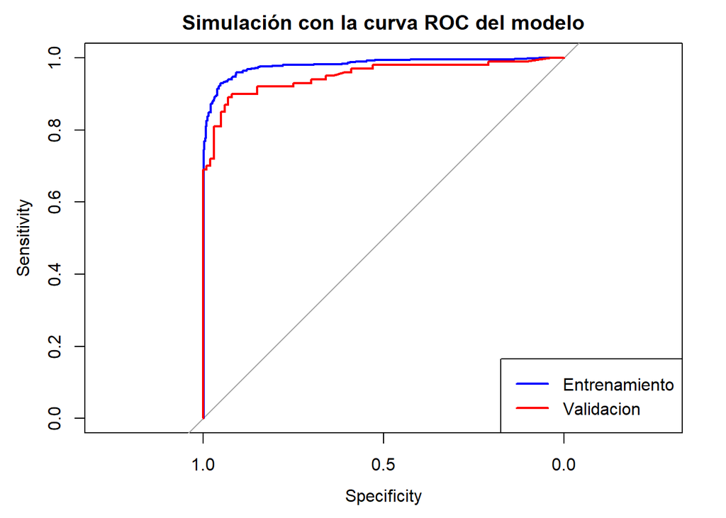

```r
plot_roc_curve(xgbTree.fit, data.training, data.testing)
```

## 4. Contraste de hipótesis

Realizamos el contraste de hipótesis y gráfico para la comparativa de los distintos modelos.

```r
# Se excluye bagging
modelos <- list(TAN=TAN.fit, HILLCLIMBING=TANHC.fit, AODE=AODE.fit, C5.0 = c5_0.fit,  RF = rf.fit, KNN = knn.fit, KKNN = kknn.fit, MLP = nn.fit, ADABOOST = adaboost.fit, GLMBOOST=glmboost.fit, LOGITBOOST=logitboost.fit, ADABAG=adabag.fit, BAG=bag.fit, XGBTREE=xgbTree.fit)
resultados <- resamples(modelos)
resultados
```

```
##
## Call:
## resamples.default(x = modelos)
##
## Models: TAN, HILLCLIMBING, AODE, C5.0, RF, KNN, KKNN, MLP, ADABOOST, GLMBOOST, LOGITBOOST, ADABAG, BAG, XGBTREE
## Number of resamples: 50
## Performance metrics: Accuracy, Kappa, ROC, Sens, Spec
## Time estimates for: everything, final model fit
```

```r
summary(resultados)
```

```
##
## Call:
## summary.resamples(object = resultados)
##
## Models: TAN, HILLCLIMBING, AODE, C5.0, RF, KNN, KKNN, MLP, ADABOOST, GLMBOOST, LOGITBOOST, ADABAG, BAG, XGBTREE
## Number of resamples: 50
##
## Accuracy
##              Min. 1st Qu. Median   Mean 3rd Qu. Max. NA's
## TAN          0.82  0.8525  0.875 0.8722  0.8900 0.92    0
## HILLCLIMBING 0.78  0.8325  0.850 0.8580  0.8800 0.94    0
## AODE         0.81  0.8600  0.875 0.8752  0.9000 0.94    0
## C5.0         0.82  0.8825  0.905 0.9042  0.9275 0.96    0
## RF           0.83  0.9000  0.910 0.9108  0.9300 0.97    0
## KNN          0.82  0.8625  0.890 0.8908  0.9100 0.96    0
## KKNN         0.86  0.8800  0.900 0.9022  0.9200 0.97    0
## MLP          0.81  0.8800  0.900 0.9022  0.9300 0.97    0
## ADABOOST     0.85  0.9000  0.910 0.9124  0.9300 0.97    0
## GLMBOOST     0.78  0.8400  0.850 0.8564  0.8800 0.92    0
## LOGITBOOST   0.80  0.8400  0.870 0.8706  0.8975 0.94    0
## ADABAG       0.79  0.8600  0.880 0.8806  0.9075 0.94    0
## BAG          0.85  0.8800  0.900 0.9002  0.9200 0.96    0
## XGBTREE      0.82  0.8825  0.900 0.8982  0.9200 0.95    0
##
## Kappa
##              Min. 1st Qu. Median   Mean 3rd Qu. Max. NA's
## TAN          0.64   0.705   0.75 0.7444   0.780 0.84    0
## HILLCLIMBING 0.56   0.665   0.70 0.7160   0.760 0.88    0
## AODE         0.62   0.720   0.75 0.7504   0.800 0.88    0
## C5.0         0.64   0.765   0.81 0.8084   0.855 0.92    0
## RF           0.66   0.800   0.82 0.8216   0.860 0.94    0
## KNN          0.64   0.725   0.78 0.7816   0.820 0.92    0
## KKNN         0.72   0.760   0.80 0.8044   0.840 0.94    0
## MLP          0.62   0.760   0.80 0.8044   0.860 0.94    0
## ADABOOST     0.70   0.800   0.82 0.8248   0.860 0.94    0
## GLMBOOST     0.56   0.680   0.70 0.7128   0.760 0.84    0
## LOGITBOOST   0.60   0.680   0.74 0.7412   0.795 0.88    0
## ADABAG       0.58   0.720   0.76 0.7612   0.815 0.88    0
## BAG          0.70   0.760   0.80 0.8004   0.840 0.92    0
## XGBTREE      0.64   0.765   0.80 0.7964   0.840 0.90    0
```

[output cut: 36 more lines]

```
##              Min. 1st Qu. Median   Mean 3rd Qu. Max. NA's
## TAN          0.72   0.800   0.84 0.8316   0.875 0.94    0
## HILLCLIMBING 0.70   0.760   0.82 0.8152   0.860 0.94    0
## AODE         0.72   0.800   0.82 0.8264   0.855 0.96    0
## C5.0         0.74   0.820   0.86 0.8592   0.900 0.94    0
## RF           0.76   0.840   0.87 0.8668   0.900 0.96    0
## KNN          0.72   0.800   0.82 0.8340   0.860 0.94    0
## KKNN         0.78   0.840   0.86 0.8636   0.895 0.96    0
## MLP          0.72   0.820   0.87 0.8636   0.900 0.96    0
## ADABOOST     0.80   0.860   0.88 0.8836   0.920 0.96    0
## GLMBOOST     0.58   0.680   0.72 0.7200   0.780 0.84    0
## LOGITBOOST   0.68   0.780   0.84 0.8292   0.880 0.94    0
## ADABAG       0.64   0.745   0.80 0.7912   0.840 0.90    0
## BAG          0.74   0.840   0.86 0.8680   0.900 0.96    0
## XGBTREE      0.72   0.820   0.86 0.8544   0.880 0.96    0
```

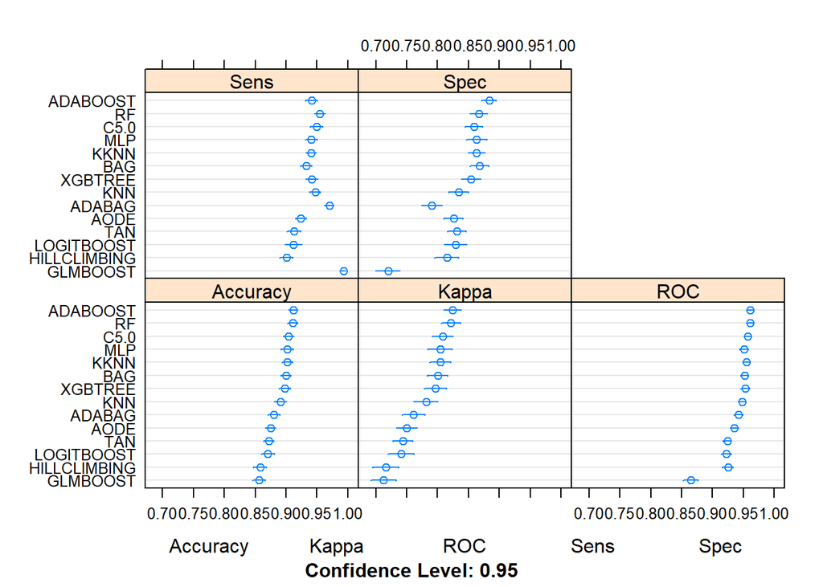

```r
dotplot(resultados)
```

```r
diferencias <- diff(resultados)
summary(diferencias)
```

```
##
## Call:
## summary.diff.resamples(object = diferencias)
##
## p-value adjustment: bonferroni
## Upper diagonal: estimates of the difference
## Lower diagonal: p-value for H0: difference = 0
##
## Accuracy
##              TAN       HILLCLIMBING AODE      C5.0      RF
## TAN                     0.0142      -0.0030   -0.0320   -0.0386
## HILLCLIMBING 1.0000000              -0.0172   -0.0462   -0.0528
## AODE         1.0000000 0.5029795              -0.0290   -0.0356
## C5.0         0.0001572 6.003e-08    0.0001856           -0.0066
## RF           7.014e-07 1.404e-09    7.425e-07 1.0000000
## KNN          1.0000000 0.0020981    0.3802708 0.1303824 0.0001759
## KKNN         0.0018891 1.401e-06    0.0009759 1.0000000 0.9065476
## MLP          0.0044592 6.798e-07    0.0008509 1.0000000 1.0000000
## ADABOOST     2.465e-07 2.238e-10    9.232e-07 0.2487575 1.0000000
## GLMBOOST     1.0000000 1.0000000    0.3774306 < 2.2e-16 < 2.2e-16
## LOGITBOOST   1.0000000 1.0000000    1.0000000 1.629e-07 2.938e-09
## ADABAG       1.0000000 0.0786924    1.0000000 8.058e-05 4.679e-08
## BAG          0.0021084 6.578e-07    0.0027577 1.0000000 0.0492901
## XGBTREE      0.0081163 6.962e-06    0.0271180 1.0000000 0.1323406
##              KNN       KKNN      MLP       ADABOOST  GLMBOOST  LOGITBOOST
## TAN          -0.0186   -0.0300   -0.0300   -0.0402    0.0158    0.0016
## HILLCLIMBING -0.0328   -0.0442   -0.0442   -0.0544    0.0016   -0.0126
## AODE         -0.0156   -0.0270   -0.0270   -0.0372    0.0188    0.0046
## C5.0          0.0134    0.0020    0.0020   -0.0082    0.0478    0.0336
## RF            0.0200    0.0086    0.0086   -0.0016    0.0544    0.0402
## KNN                    -0.0114   -0.0114   -0.0216    0.0344    0.0202
## KKNN         0.0539584            0.0000   -0.0102    0.0458    0.0316
## MLP          0.1634944 1.0000000           -0.0102    0.0458    0.0316
## ADABOOST     0.0001335 0.2999843 0.6624416            0.0560    0.0418
## GLMBOOST     3.632e-09 7.309e-14 1.424e-12 < 2.2e-16           -0.0142
## LOGITBOOST   0.0012689 4.184e-06 7.895e-08 6.551e-10 0.1099257
## ADABAG       1.0000000 0.0002971 0.0001269 8.726e-08 3.892e-05 1.0000000
## BAG          1.0000000 1.0000000 1.0000000 0.0108594 1.634e-13 3.540e-07
## XGBTREE      1.0000000 1.0000000 1.0000000 0.1420865 1.953e-10 1.755e-05
##              ADABAG    BAG       XGBTREE
```

[output cut: 187 more lines]

```
##              LOGITBOOST ADABAG     BAG        XGBTREE
## TAN           2.400e-03  4.040e-02 -3.640e-02 -2.280e-02
## HILLCLIMBING -1.400e-02  2.400e-02 -5.280e-02 -3.920e-02
## AODE         -2.800e-03  3.520e-02 -4.160e-02 -2.800e-02
## C5.0          3.000e-02  6.800e-02 -8.800e-03  4.800e-03
## RF            3.760e-02  7.560e-02 -1.200e-03  1.240e-02
## KNN           4.800e-03  4.280e-02 -3.400e-02 -2.040e-02
## KKNN          3.440e-02  7.240e-02 -4.400e-03  9.200e-03
## MLP           3.440e-02  7.240e-02 -4.400e-03  9.200e-03
## ADABOOST      5.440e-02  9.240e-02  1.560e-02  2.920e-02
## GLMBOOST     -1.092e-01 -7.120e-02 -1.480e-01 -1.344e-01
## LOGITBOOST               3.800e-02 -3.880e-02 -2.520e-02
## ADABAG       0.0001719             -7.680e-02 -6.320e-02
## BAG          5.531e-05  < 2.2e-16              1.360e-02
## XGBTREE      0.0553355  < 2.2e-16  0.6361091
```

## 5. Tabla resumen con las métricas

Damos una tabla comparativa con las distincas métricas para cada uno de los modelos entrenados:

```r
Result <- function ( modelos ){
  n_modelos = length(modelos)
  comparativa <- matrix(0, n_modelos, 7)
  pred <- NULL
  data_testing <- NULL
  for (i in 1:n_modelos){
    if(modelos[[i]]$method == "custom") {
      data_testing <- data.testing.d
    }
    else {
      data_testing <- data.testing
    }
    pred[[i]] <- predict(modelos[i], data_testing, type="prob")
    comparativa[i,1] = modelos[[i]]$method
    if (modelos[[i]]$method == "treebag"){
       comparativa[i,2] = "-"
       comparativa[i,3] = "-"
       comparativa[i,4] = "-"
       comparativa[i,5] = modelos[[i]]$results$Accuracy
       comparativa[i,6] = modelos[[i]]$results$Kappa
    }else{
       comparativa[i,2] = modelos[[i]]$results[rownames(modelos[[i]]$bestTune), c("ROC")]
       comparativa[i,3] = modelos[[i]]$results[rownames(modelos[[i]]$bestTune), c("Sens")]
       comparativa[i,4] = modelos[[i]]$results[rownames(modelos[[i]]$bestTune), c("Spec")]
       comparativa[i,5] = modelos[[i]]$results[rownames(modelos[[i]]$bestTune), c("Accuracy")]
       comparativa[i,6] = modelos[[i]]$results[rownames(modelos[[i]]$bestTune), c("Kappa")]
    }
    comparativa[i,7] = auc(roc(data_testing$y,pred[[i]][[1]][,"Yes"]))
  }
  colnames(comparativa) <- c("Modelo", "ROC", "Sens", "Spec", "Accuracy", "Kappa", "ROC Validación")
  return(comparativa)
}

modelos <- list(TAN=TAN.fit, HILLCLIMBING=TANHC.fit, AODE=AODE.fit, C5.0 = c5_0.fit,  RF = rf.fit, KNN = knn.fit, KKNN = kknn.fit, MLP = nn.fit, ADABOOST = adaboost.fit, GLMBOOST=glmboost.fit, LOGITBOOST=logitboost.fit, ADABAG=adabag.fit, BAG=bag.fit, XGBTREE=xgbTree.fit)
Result(modelos)
```

```
##       Modelo       ROC        Sens     Spec     Accuracy Kappa
##  [1,] "custom"     "0.924304" "0.9128" "0.8316" "0.8722" "0.7444"
##  [2,] "custom"     "0.925216" "0.9008" "0.8152" "0.858"  "0.716"
##  [3,] "custom"     "0.9357"   "0.924"  "0.8264" "0.8752" "0.7504"
##  [4,] "C5.0"       "0.95762"  "0.9492" "0.8592" "0.9042" "0.8084"
##  [5,] "parRF"      "0.961464" "0.9548" "0.8668" "0.9108" "0.8216"
##  [6,] "knn"        "0.947908" "0.9476" "0.834"  "0.8908" "0.7816"
##  [7,] "kknn"       "0.955436" "0.9408" "0.8636" "0.9022" "0.8044"
##  [8,] "mlp"        "0.951144" "0.9408" "0.8636" "0.9022" "0.8044"
##  [9,] "adaboost"   "0.961536" "0.9412" "0.8836" "0.9124" "0.8248"
## [10,] "glmboost"   "0.864976" "0.9928" "0.72"   "0.8564" "0.7128"
## [11,] "LogitBoost" "0.922452" "0.912"  "0.8292" "0.8706" "0.7412"
## [12,] "AdaBag"     "0.94232"  "0.97"   "0.7912" "0.8806" "0.7612"
## [13,] "treebag"    "-"        "-"      "-"      "0.9002" "0.8004"
## [14,] "xgbTree"    "0.953304" "0.942"  "0.8544" "0.8982" "0.7964"
##       ROC Validación
##  [1,] "0.9206"
##  [2,] "0.9209"
##  [3,] "0.931"
##  [4,] "0.9672"
##  [5,] "0.96195"
##  [6,] "0.94115"
##  [7,] "0.95395"
##  [8,] "0.9459"
##  [9,] "0.955"
## [10,] "0.8577"
## [11,] "0.88975"
## [12,] "0.9318"
## [13,] "0.9594"
## [14,] "0.9498"
```

## 6. Selección del mejor modelo

Tomando como métrica de referencia la curva ROC, no se ve ni en los contrastes de hipótesis, ni en las gráficas ni en las tablas resumen una diferencia significativa entre los tres modelos de redes bayesianas. Los tres clasifican correctamente los datos sin diferencias significativas desde el punto de vista estadístico. Sin embargo, los contrastes de hipótesis sí detectan (p < 0.05) una diferencia significativa entre el modelo xgbtree y los modelos de redes bayesianas, siendo mejor predictor elprimero citado. No se hace la comparativa con el resto de modelos, ya que no son propios de este módulo.